# EDS 222: Assignment 02 (due: Oct 08, 5pm)

Julia Parish

2021-10-08

# Question 1: Probability density functions in `R`

`R` has many built-in functions that let you describe, analyze, and sample from common probability density functions. For example, if you type `?stats::Normal` in your console, you’ll see documentation on all the functions relevant to the normal distribution. These functions include:

- `dnorm(x, mean = 0, sd = 1)`, which returns the *density* of the normal distribution evaluated at whatever values you pass in via `x`. You can think of the output of `dnorm()` as the *height* of the normal pdf at the value `x`. Note that this function defaults to a normal distribution with $\mu = 0$ and $\sigma = 1$, but you can of course change that.
- `pnorm(q, mean = 0, sd = 1)`, which returns the *cumulative probability* of the normal distribution evaluated at whatever values you pass in via `q`. You can think of the output of `pnorm()` as the *area* under the pdf to the left of the value `q`. Again, note the default distribution parameters $\mu$ and $\sigma$.

## Question 1.1

```r
# create a object that contains a sequence of -4, 4, 0.01
x = seq(-4, 4, 0.01)
```

Use `dnorm()` to compute the density of the normal pdf for all values in the `x` vector generated above, using $\mu = 0$ and $\sigma = 1$. Use `geom_polygon()`, `geom_line()`, or `geom_point()` (take your pick) to plot this pdf over the support given in `x`.

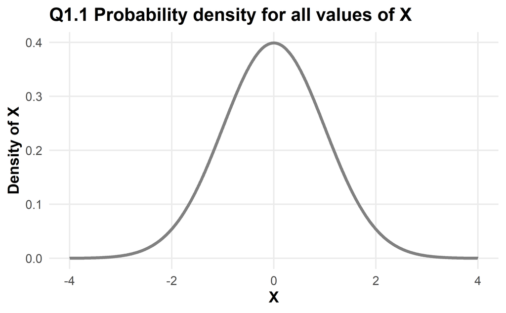

## Question 1.2

Use the densities you generated in 1.1 to calculate the probability that a random variable distributed normally with mean 0 and standard deviation 1 falls between -2 and 2.

Hint: Remember that
$$Pr(A\leq x \leq B) = \int_A^B f(x)dx$$
where the integral is a fancy way to tell you to sum up $f(x)$ over values of $x$ from $A$ to $B$.

- Q1.2 The probability that a value of `x` falls between -2 and 2 is 95%.

## Question 1.3

Repeat the last two questions, but let $\sigma=2$. Describe why your answer changes in the direction that it does under this new normal distribution.

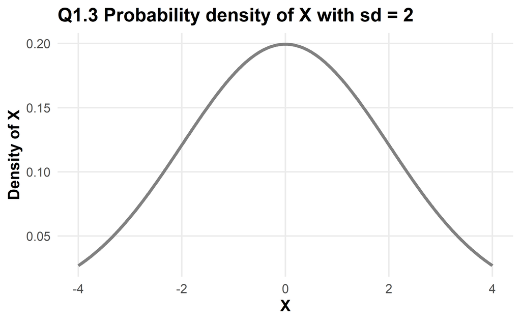

- Q1.3 The probability that a value of `x` with a $\sigma=2$ falls between -2 and 2 is 68%.

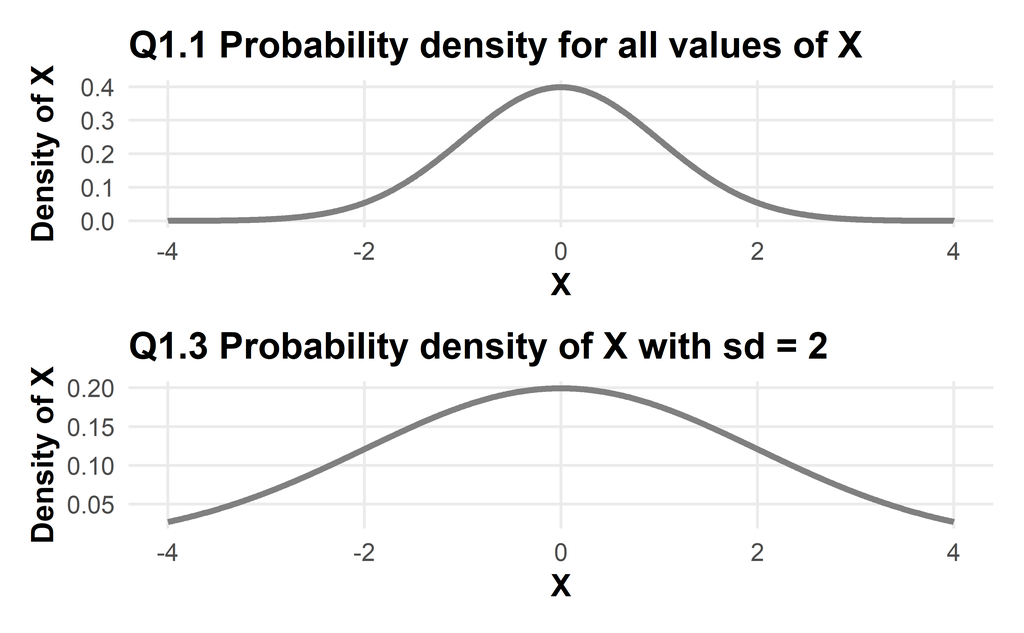

- Q1.3 The standard deviation increased from 1 to 2, which increased the variance, or dispersal, of the density of X. This increase of the standard deviation widen and lower the density of X. The density of X was lowered to a maximum range of 0.2 versus a maximum of 0.4 when the standard deviation was 1.

## Question 1.4

An analogous set of functions computes densities and probabilities for the **log normal** distribution, a distribution with skew. These functions are `dlnorm()` and `plnorm()` and operate as above for the normal distribution functions.

Use `plnorm()` under default parameters to compute the probability that a random variable distributed log normal takes on a value above 2. Use `pnorm()` to compute the corresponding probability for the normal distribution under default parameters. Why are these values so different?

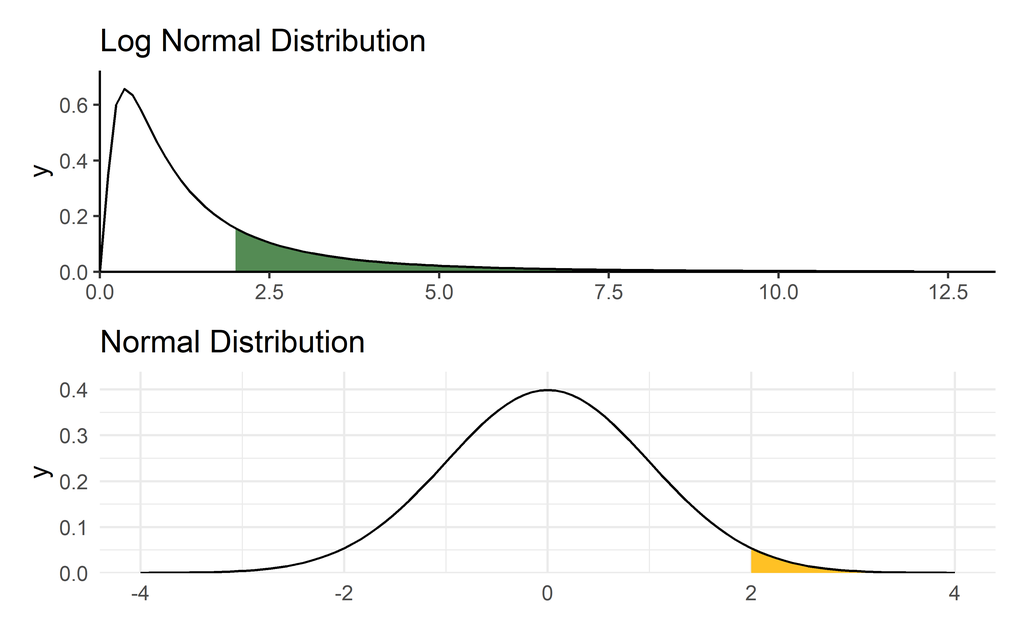

# Question 2: Climate summary statistics

In the following questions, you’ll be working with climate data from Colombia. These data were obtained from the [ERA5 database](https://www.ecmwf.int/en/forecasts/datasets/reanalysis-datasets/era5), a product made available by the European Centre for Medium-Range Weather Forecast. The high-resolution hourly gridded data were aggregated to the municipality by month level – that is, each observation in these data report a monthly average temperature value and a monthly cumulative precipitation value for one of the 1,123 municipalities across the country.

Note: The computational techniques we use to go from raw, spatial, gridded data to a tabular dataset at an administrative level are really valuable for environmental data science. We’ll cover these spatial and temporal aggregation techniques in the second half of the course.

These data – stored in `colombia_climate.csv` – cover all municipalities for the period 1996 to 2015. Climate scientists tend to describe the “climate” of a location as the probability density function of a large set of climate variables over about a 30 year period. We only have 20 years, but we will consider our sample as randomly drawn temperature and precipitation realizations from the “climate” p.d.f. over this period. We are aiming to draw conclusions about the Colombian climate using this sample of temperature and precipitation observations.

## Question 2.1

Read these data into `R` using the `read.csv()` function.

See the README.rtf file for details on the variables in `colombia_climate.csv`.

For each of the temperature and rainfall variables, create a histogram that shows the distribution of the variable across the entire sample. For each variable, answer the following questions:

- Is the distribution symmetric or skewed?
- Is there a long tail (or two), or does this distribution look approximately normally distributed?
- Is the distribtion unimodal, bimodal, or multimodal?

Temperature Distribution

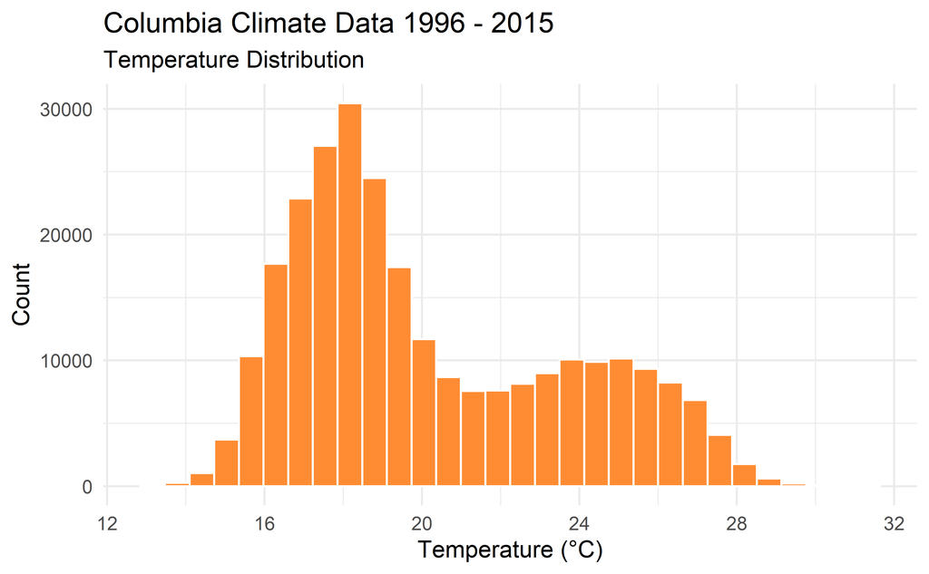

- Q2.1 Temperature - The temperature distribution is right-skewed with an insignificant tail and is bi-modal.

Precipitation Distribution

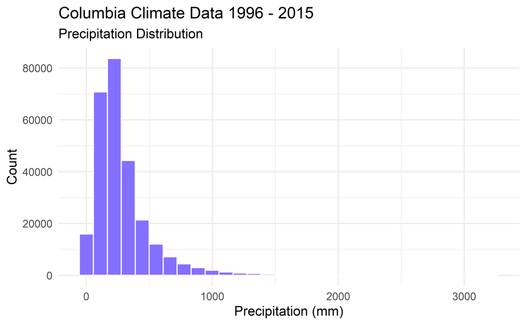

*Q2.1 Precipitation - The precipitation distribution is right-skewed with a long tail and is uni-modal. There are precipitation data points up to 3215.26 mm.

## Question 2.2

Add on top of your histograms vertical lines indicating the mean and the median. What does the difference between those two lines tell you about these distributions?

Temperature Distribution - Mean & Median

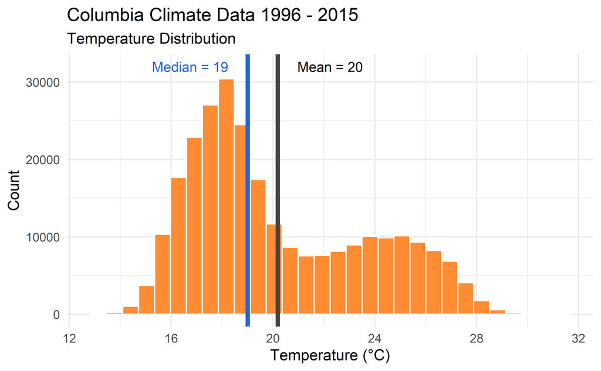

- Q2.2 Temperature - The mean (20°C) and median (19°C) for the temperature variable are very close to being equal, which indicates the data is not significant skewed, or there is not a lot of outlier data points. These relatively close values proves the distribution does not have a long tail.

Precipitation Distribution - Mean & Median

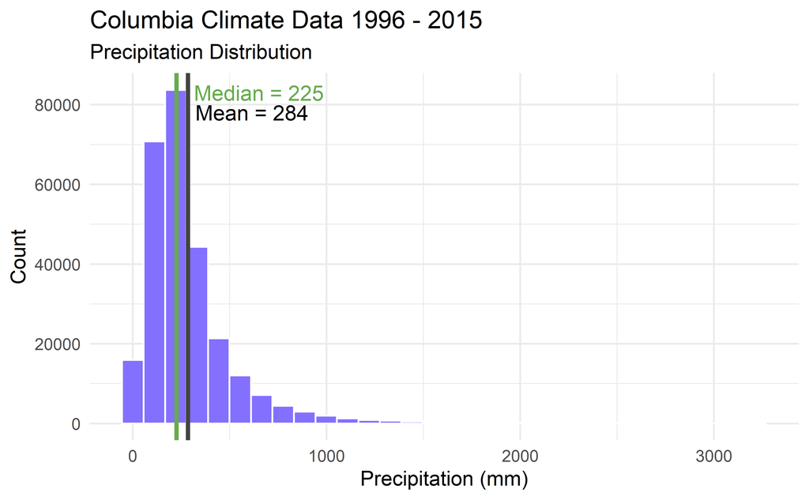

- Q2.3 Precipitation - The mean (284 mm) and median (225 mm) for precipitation variable are not as close as they were with the temperature variable. The mean is influenced by significant outliers within the precipitation data. The maximum value for the precipitation data is 3215 mm. This value is significantly greater than either the mean or the median, which indicates that the majority of the data is clustered in the lower values and that this distribution is skewed to the right.

## Question 2.3

Anthropogenic climate change is expected to raise temperatures across Colombia, increase total precipitation, and increase variability in precipitation. Compute the mean, the median, and the standard deviation of each climate variable in:

- The full sample
- Before 2005
- After 2005

Put your summary statistics into a table. Are the changes over time in these summary statistics consistent with climate change? If so, why? If not, why not?

Columbia Climate Data Summary

| Data Source | Precipitation Mean | Precipitation Median | Precipitation Std Dev | Temperature Mean | Temperature Median | Temperature Std Dev |
| --- | --- | --- | --- | --- | --- | --- |
| full climate data | 284 | 225 | 237 | 20.2 | 19 | 3.48 |
| pre2005 | 255 | 205 | 216 | 20.2 | 19 | 3.45 |
| post2005 | 313 | 246 | 253 | 20.2 | 19 | 3.50 |

- Q2.3 - There has been an increase in the average precipitation since 2005. The average temperature has stayed constant in each parameter, though the standard deviation has increased in the years after 2005. These summary statistics may indicate climate change influences, but the time scale (1996-2015) is too truncated to clearly answer is climate change is influencing the climate of Columbia.

## Question 2.4

Tables are nice, but often a visual can help communicate key summary statistics. Use `geom_boxplot()` in `ggplot2` to make a box plot of each variable, using the default quantile options.

See Week 2 lab answers for tips on box plots. Make sure your box plot shows the 1st, 2nd, and 3rd quartiles.

- What do these boxplots suggest about outliers in each variable? What about skew?

Note: A cool alternative to the standard boxplot is a “raincloud” plot, which helps visualize the quantiles and the underlying data. If you’re interested, more info [here](https://www.cedricscherer.com/2021/06/06/visualizing-distributions-with-raincloud-plots-and-how-to-create-them-with-ggplot2/) – feel free to show a raincloud plot in place of a boxplot if you want to get fancy.

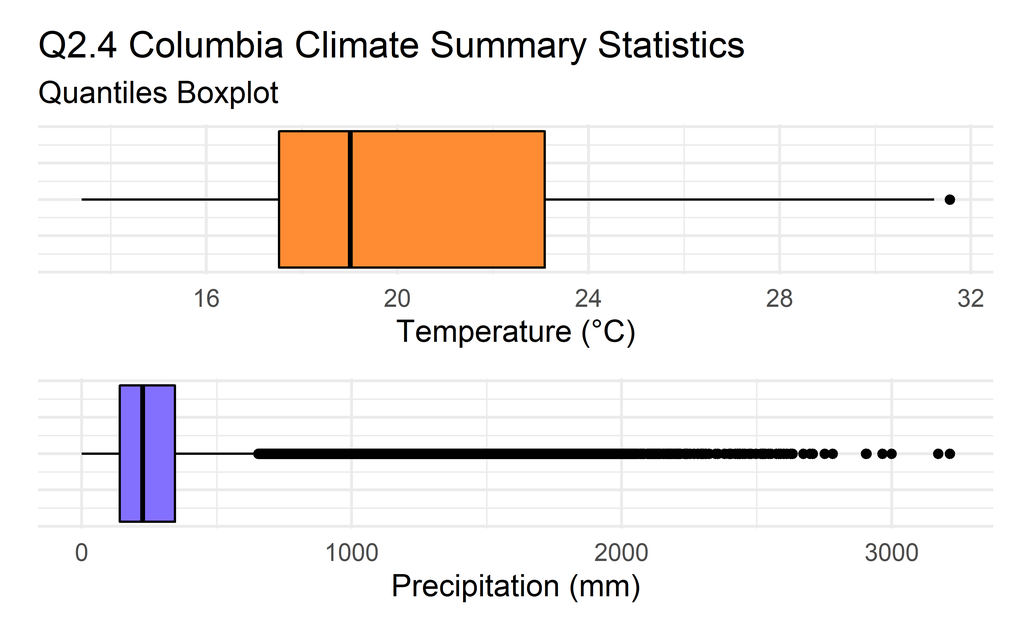

Q2.4 Boxplots - The boxplots visualize data outliers well. The boxplot for temperature values shows there is temperature range (17.5°C - ~23°C) where the majority of the data points fall, and there are very few outliers. It also shows that those outliers are not too extreme as the minimum value is 13.4°C and the maximum value is 31.6°C. This limited outlier range reflects there is a relatively small skew in the temperature distribution. The precipitation boxplot best visualizes the data skew, and how extreme the right skew actually is.

## Question 2.5

The histograms, summary statistics, and box plots should make you concerned that these data are not normally distributed. As we will show later in the course, it’s often very helpful to have normally distributed data before we do things like linear regressions or hypothesis testing. Here, let’s use a Q-Q plot to assess the normality of our sample data.

- Use `geom_qq()` and `geom_qq_line()` in `ggplot2` to make a Q-Q plot for each variable.

  `geom_qq_line()` lets you draw a line indicating where the sample quantiles would lie if the data were normally distributed.
- What do you conclude about the normality of these two variables?

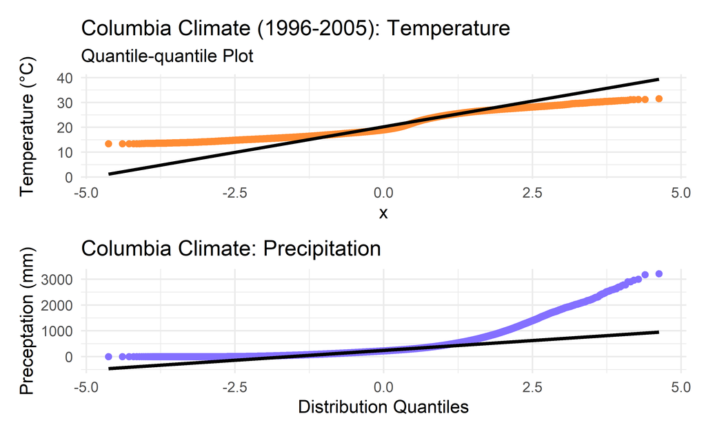

- Q2.5 These QQ plots visualize that neither data variables, temperature and precipitation, are normally distributed. For both temperature and precipitation, a majority of the quantile points do not fall on the theoretical normal line.

## Question 2.6

When our sample observations are not normally distributed, we often rely on nonlinear transformations to reshape our data. If we compute a nonlinear transformation on our underlying data and they then look closer to normal, we can use this transformed version of our variable in later statistical analysis.

Any mathematical operation that is a nonlinear function of the underlying variable can be considered a “nonlinear transformation”. For example, $x^2$ and $log(x)$ are both nonlinear transformations.

Because we tend to see a lot of variables in the world that follow the lognormal distribution, a very common nonlinear transformation is the natural logarithm. Transform the precipitation data by taking the natural logarithm. Then remake your Q-Q plot – does your variable (defined as `log(precip)`) now look closer to normally distributed? What can you learn about where the data diverge from the normal distribution?

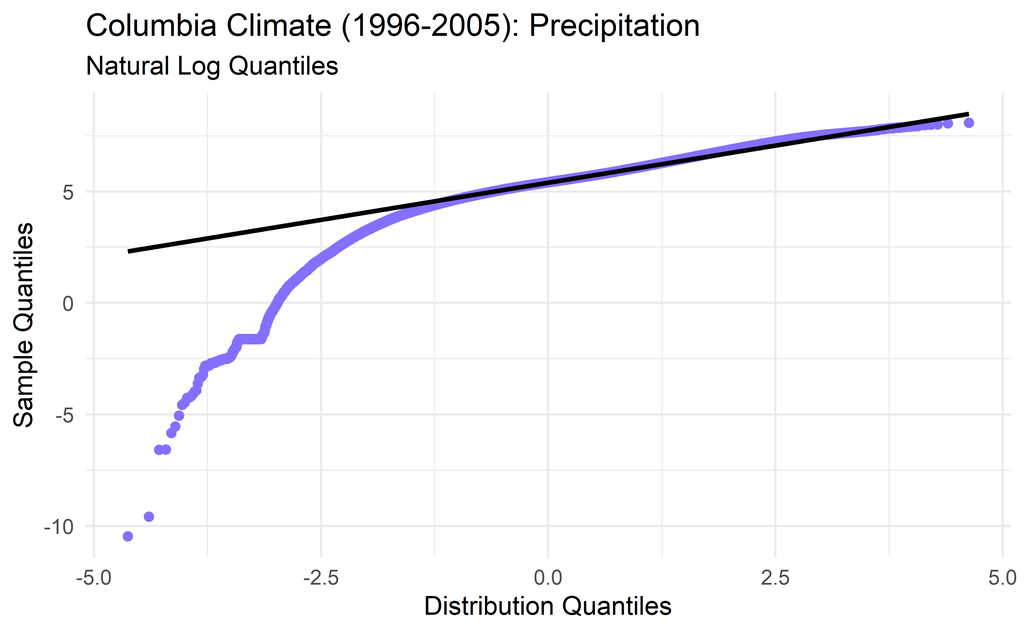

## Question 2.7: Winsorization

As discussed in class, outliers can have a large influence over some, but not all, summary statistics. A common technique for handling outliers that may be overly influencing a statistical analysis is called “winsorization”. This process caps observations at a given percentile of the distribution. For example, winsorizing at the 99th percentile would replace all observations above the 99th percentile with the value of the 99th percentile. This is justified if you have reason to believe those outliers are truly “high” observations, but that their extreme level is unbelievable.

This happens often in rate data when the denominator is small. For example, a sample of crime rates from across the US may contain extreme rate estimates in locations with small total population because a small denominator leads to very noisy estimates of the rate. However, winsorization represents a direct manipulation of your data, and there are many cases where it is is not a reasonable thing to do, even if it is convenient for removing pesky outliers. Be thoughtful about this in practice!

- Our precipitation sample in Colombia appears to have quite a few outliers. Implement winsorization at the 90th, 95th, and 99th percentiles for precipitation only. Make a table that reports, for each level of winsorization, the sample mean, median, 75th percentile, and standard deviation.
- Which summary statistics change across the different winsorization levels? Explain why this is the case.

Columbia Climate Percipitation Summary

| Data Source | Precipitation Mean | Precipitation Median | 75th Percentile | Precipitation Std Dev |
| --- | --- | --- | --- | --- |
| 90th_Percentile | 256 | 225 | 346 | 152 |
| 95th_Percentile | 269 | 225 | 346 | 181 |
| 99th_Percentile | 281 | 225 | 346 | 220 |

- Q2.7 The precipitation mean and standard deviation changed across the percentile levels. For each increase in percentile, you are including more precise data which influences the mean and the standard deviation. The standard deviation increases with each percentile demonstrating more variability in the data when there are more true data points, but the accuracy also increases. The median does not change when selecting for the three different percentiles as the center point of the data is not influenced.